# Mapping Osprey Migrations to Understand Parasite Spread

```python
import matplotlib.pyplot as plt
import matplotlib.image as mpimg
```

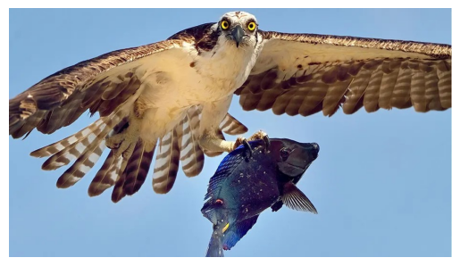

```python
img = mpimg.imread('/workspaces/species-distribution-coding-challenge-annaposlednik/notebooks/ospreyfish.jpg')
imgplot = plt.imshow(img)

# Remove axes, ticks, and labels
plt.axis('off')

# Show the image without plotlines
plt.show()
```

Photo of an osprey holding a blue tang in Aruba, photographer: Michiel Oversteegen.

## *Pandion haliaetus*

Osprey (*Pandion haliaetus*) are charismatic raptors that are most known for their diving ability, as their diet is largely composed of live fish. Osprey migrate annually in the spring and fall between North America for breeding and the Carribbean and South America for the winter. These large hawks have a life-span of 15-20 years and log upwards of 160,000 miles in their lifetime.

Osprey's diet of live fish, makes these birds of prey definitive hosts for a number of different marine parasites, including the trematode *Scaphanocephallus sp.* which causes black spot syndrome in Carribbean fish. This syndrome is emerging across fish species and islands of the Carribbean, and may pose implications for coral reef ecosystems, as this parasite is known to infect a number of important herbivorous fish that feed on algae. One hypothesis for why scientists are seeing a recent emergence of this parasite in the Carribbean could be linked to osprey populations rebounding following the ban on DDT, allowing for greater spread of the parasite through osprey migrations. To better understand the possible extent of the spread, range, and transmission of this parasite, I chose to map the migrations of osprey.

## Data Description

Data on osprey observations were taken from the [Global Biodiversity Information Facility](https://www.gbif.org/what-is-gbif/) (GBIF), which is an international network that provides free and open access biodiversity data about all types of life on Earth. This network provides data collected from a variety of sources including museum specimens, DNA barcoding, and smartphone photos.

For this analysis data on ospreys (*Pandion haliaetus*) migration for the year 2023 was downloaded from GBIF.

[Ecoregion data](https://www.geographyrealm.com/terrestrial-ecoregions-gis-data/) was used from [RESOLVE Ecoregions dataset](https://developers.google.com/earth-engine/datasets/catalog/RESOLVE_ECOREGIONS_2017). All ecoregions were included.

## Methods Description

Osprey occurrence data was filtered to include all occurrences from 2023 with coordinates available, and downloaded from GBIF. This dataframe, which included month and coordinates as geometry, was then converted to a GeoDataFrame using geopandas using the WGS84 projection as the coordinate reference system. Then, ecoregion data from RESOLVE was spatially joined with the osprey occurrence data for each month and location name, matching the WGS84 CRS. Monthly observations were counted for each region and then normalized by space and time. This involved taking mean occurrence for each month and ecoregion and diving the counts by both the mean occurrence per month and mean occurrence per region, to take into account the biases of crowd-sourced data (given we expect to see greater occurrences in locations and times with higher human activity). The normalized data was then plotted using hvplot, producing an interactive plot that depicts monthly migration patterns of osprey across 2023.

## Osprey exhibit a global distribution with migrations to the North in spring and summer months.

[figure not shown]

This interactive plot depicts the occurrence observations of osprey across the months of 2023. Osprey have a global distribution, generally found around coasts and waterways, which is most clearly illustrated in Australia in the map above. Osprey begin to be observed at higher frequencies at Northern latitudes in April, and migrate towards equitorial regions beginning in September and October. The large-scale migrations of osprey suggest that osprey may be spreading parasites, particularly trematodes (flatworms) of fish, massive distances which could frustrate management of any diseases these parasites may cause to fish and other intermediate hosts.

## Citations

Global Biodiversity Information Facility. (2024). GBIF Occurrence Download [Data set]. https://doi.org/10.15468/dl.jqrwjf

RESOLVE. (2017). RESOLVE Ecoregions dataset [Data set]. https://doi.org/10.1093/biosci/bix014

Cornell Lab of Ornithology. (n.d.). Osprey. All About Birds.https://www.allaboutbirds.org/guide/Osprey/overview

Virginia Institute of Marine Science (n.d.) About Ospreys. https://www.vims.edu/bayinfo/ospreycam/about_ospreys/#:~:text=Young%2Dof%2Dthe%2Dyear,before%20making%20their%20return%20migration